# Exportación Café

Miguel Muñoz, Axel Escobar, Juan Alarcon, Daniel González

Diciembre

# Serie de Tiempo de Exportación de Café

Se realizará el ajuste por 3 modelos los cuales son:

- Suavizamiento Exponencial (Holt Winters)
- Red Neuronal Recurrente (Jordan)
- Árboles de decisión

**Vamos a leer la base de datos**

```r
library(tseries)
library(readxl)
library(tidyverse)
library(FitAR)
library(forecast)
Expor_cafe <-read_excel("Exportacion_cafe.xlsx")
```

Nos fijamos en la carga de café desde enero del año 1958 hasta enero del 2021

```r
Exportacion_cafe <- ts(Expor_cafe[,2], start = c(1958,1), end = c(2021,1), frequency = 12)
Exportacion_cafe
```

```
##           Jan      Feb      Mar      Apr      May      Jun      Jul      Aug
## 1958  337.000  450.000  383.000  334.000  331.000  340.000  485.000  483.000
## 1959  443.000  483.000  384.000  490.000  598.000  502.000  557.000  604.000
## 1960  439.000  540.000  381.000  387.000  412.000  348.000  369.000  447.000
## 1961  463.000  528.000  245.000  527.000  444.000  505.000  437.000  473.000
## 1962  373.000  460.000  367.000  415.000  496.000  647.000  531.000  713.000
## 1963  310.000  253.000  472.000  560.000  471.000  470.000  557.000  752.000
## 1964  554.000  614.000  444.000  760.000  579.000  196.000  429.000  401.000
## 1965  275.000  465.000  490.000  440.000  482.000  519.000  527.000  705.000
## 1966  487.000  571.000  273.000  658.000  481.000  344.000  473.000  532.000
## 1967  323.000  524.000  458.000  396.000  511.000  539.000  506.000  631.000
## 1968  556.000  585.000  380.000  570.000  499.000  601.000  618.000  665.000
## 1969  239.000  477.000  657.000  404.000  648.000  705.000  383.000  479.000
## 1970  534.000  620.000  788.000  463.000  579.000  687.000  316.000  434.000
## 1971  397.000  429.000  654.000  386.000  515.000  744.000  346.000  845.000
```

[output cut: 115 more lines]

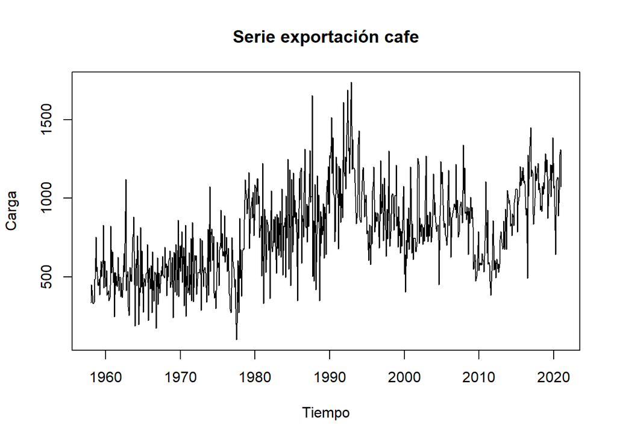

```r
plot(Exportacion_cafe,type="l",xlab="Tiempo",ylab="Carga",main="Serie exportación cafe")
```

Vemos que la serie no muestra estacionariedad y vemos que su varianza marginal no es muy grande pero aún así no es constante.

Veamos una descomposición aditiva de la serie de tiempo

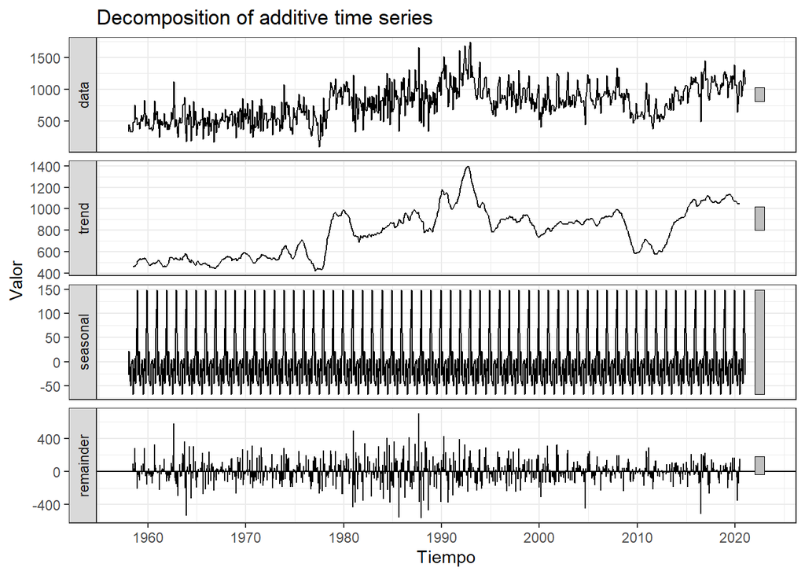

```r
Dec<-decompose(Exportacion_cafe,type = 'additive')
autoplot(Dec)+
  labs(tittle="Descomposición serie de tiempo Exportación de Café",
       x="Tiempo",y="Valor", colour="Gears")+
  theme_bw()
```

Apliquemos transformación de Box Cox para visualizar que tanto se estabiliza la varianza marginal

```r
forecast::BoxCox.lambda(Exportacion_cafe, method = "guerrero", lower = -1, upper = 3) ###Me entrega el valor de lambda
```

```
## [1] 0.7169386
```

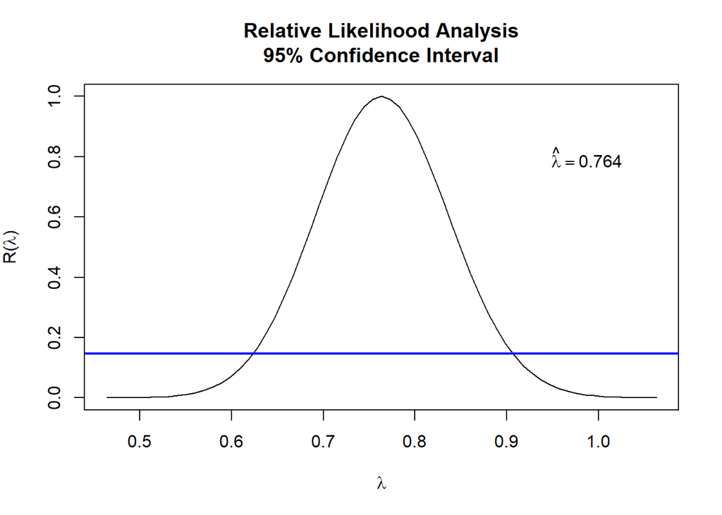

```r
##method="loglik"
FitAR::BoxCox(Exportacion_cafe)
```

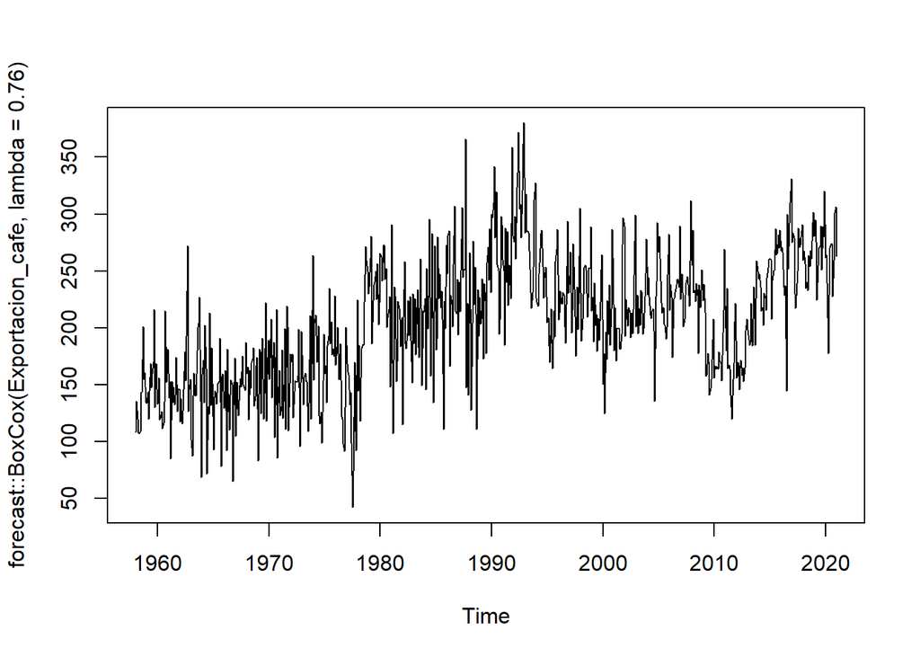

```r
Texportacion_cafe<-(Exportacion_cafe)^0.76
plot(forecast::BoxCox(Exportacion_cafe,lambda=0.76),type="l")
```

Vamos a aplicar una diferenciación a nuestra serie transformada

```r
ndiffs(Texportacion_cafe)
```

```
## [1] 1
```

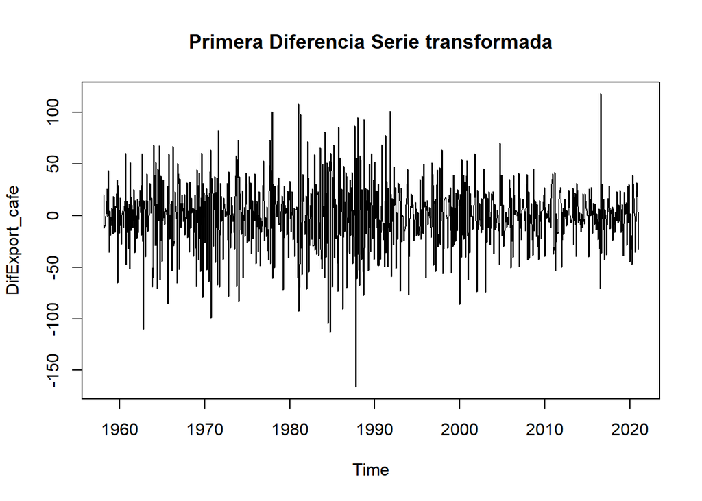

```r
DifExport_cafe <- diff(Texportacion_cafe, lag = 1)
plot(DifExport_cafe ,type="l", main="Primera Diferencia Serie transformada")
```

## Suavizamiento Exponencial(Holt-Winters)

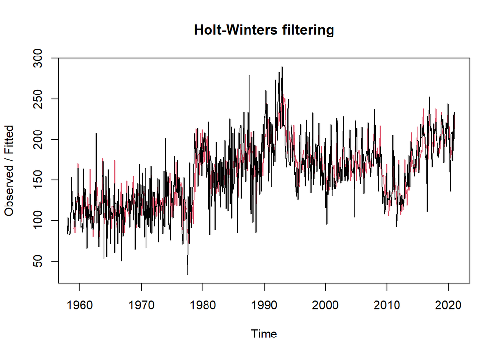

```r
HWEC=stats::HoltWinters(Texportacion_cafe,seasonal="additive")
plot(HWEC)
```

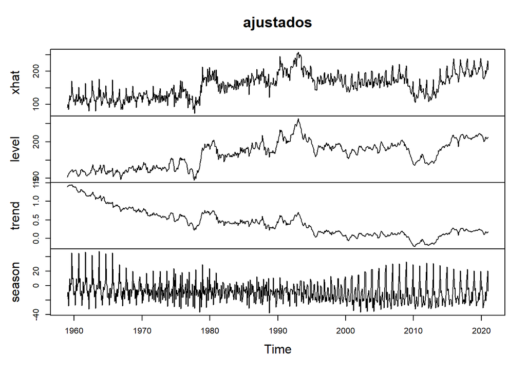

```r
ajustados=fitted(HWEC)
plot(ajustados)
```

Veamos los valores predichos para los siguientes 8 meses, esto es, hasta septiembre de 2021

```r
Predicciones=predict(HWEC, 8, prediction.interval = T)
Predicciones
```

```
##               fit      upr      lwr
## Feb 2021 208.6456 260.9808 156.3103
## Mar 2021 196.9139 250.5025 143.3253
## Apr 2021 175.3052 230.1327 120.4776
## May 2021 188.2326 244.2857 132.1795
## Jun 2021 196.3314 253.5976 139.0652
## Jul 2021 195.8904 254.3581 137.4227
## Aug 2021 205.3436 265.0020 145.6853
## Sep 2021 189.6262 250.4651 128.7872
```

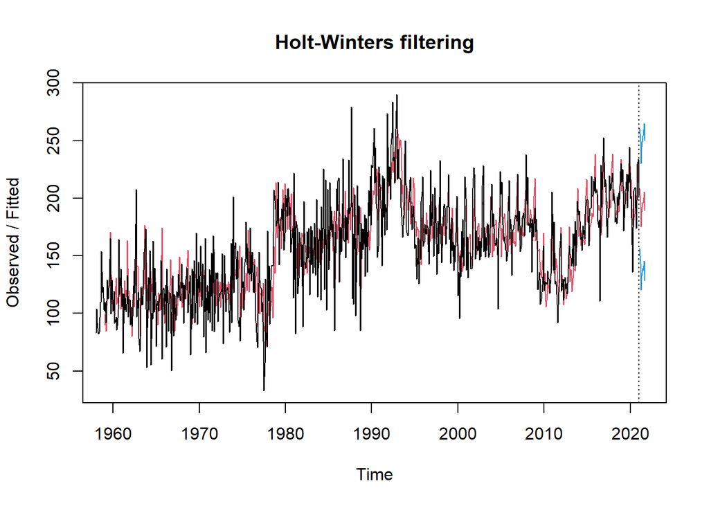

```r
plot(HWEC, Predicciones)
```

Observamos los valores predichos para los últimos 8 meses

```r
Predic=(Predicciones)^(1/0.76)
Predic
```

```
##                fit      upr      lwr
## Feb 2021 1126.8189 1512.684 770.5943
## Mar 2021 1044.2023 1433.282 687.4906
## Apr 2021  896.1104 1281.936 547.0596
## May 2021  984.0552 1386.664 618.0238
## Jun 2021 1040.1400 1456.629 660.7303
## Jul 2021 1037.0670 1462.379 650.4814
## Aug 2021 1103.4140 1543.426 702.4242
## Sep 2021  993.6525 1433.000 597.2393
```

## Red Neuronal Recurrente para la serie de tiempo

```r
Exportacion_cafe <- ts(Expor_cafe[,2], start = c(1958,1), end = c(2021,9), frequency = 12)
```

Cargamos las librerias correspondientes

```r
library(RSNNS)
library(zoo)
library(quantmod)
```

Normalicemos la variable correspondiente a la carga de café

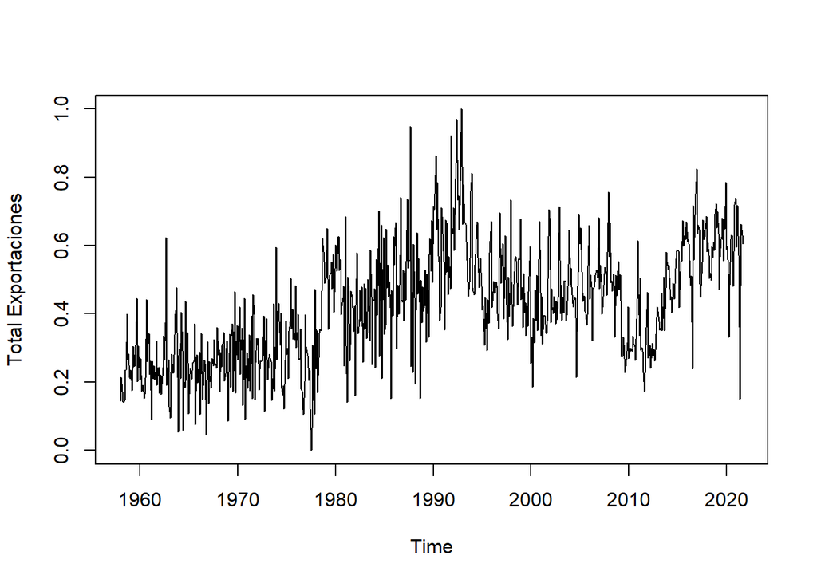

```r
Z<-as.ts(Exportacion_cafe,F)
N<-(Z-min(Z))/(max(Z)-min(Z))
plot(N)
```

```r
length(N)
```

```
## [1] 765
```

Creamos asignaciones de los datos correspondientes a entrenamiento y prueba

```r
Ttrain<-round(length(N)*0.75,digits = 0)
train <- 0:(Ttrain-1)
test <- (Ttrain):length(N)
```

Creación de las variables rezagadas

```r
R <- as.zoo(N)
x1 <- Lag(R, k = 1)
x2 <- Lag(R, k = 2)
x3 <- Lag(R, k = 3)
x4 <- Lag(R, k = 4)
x5 <- Lag(R, k = 5)
x6 <- Lag(R, k = 6)
x7 <- Lag(R, k = 7)
x8 <- Lag(R, k = 8)
x9 <- Lag(R, k = 9)
x10 <- Lag(R, k = 10)
x11 <- Lag(R, k = 11)
x12 <- Lag(R, k = 12)
RN <- cbind(R,x1,x2,x3,x4,x5,x6,x7,x8,x9,x10,x11,x12)
```

Eliminamos los NA’s y creamos los objetos de entrada y salida de la red neuronal

```r
RN <- RN[-(1:12),]

Entradas <- RN[,2:13]
Salidas <- RN[,1]
```

### Configuramos la red neuronal

```r
set.seed(1234)
Red <-jordan(Entradas[train],Salidas[train],size=10,learnFuncParams=c(0.1),maxit=78000)
```

Vemos cómo evoluciona el error de la red con el número de iteraciones

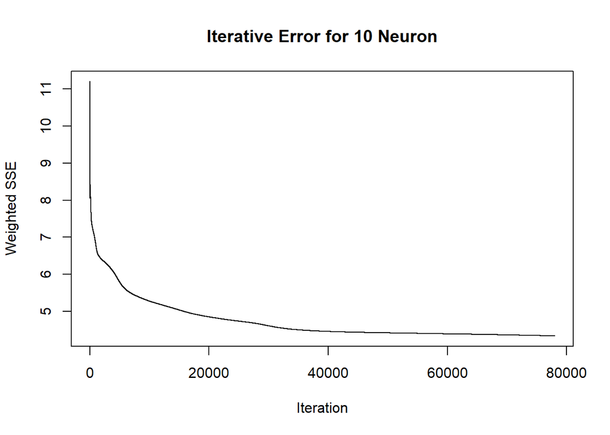

```r
plotIterativeError(Red, main = "Iterative Error for 10 Neuron")
```

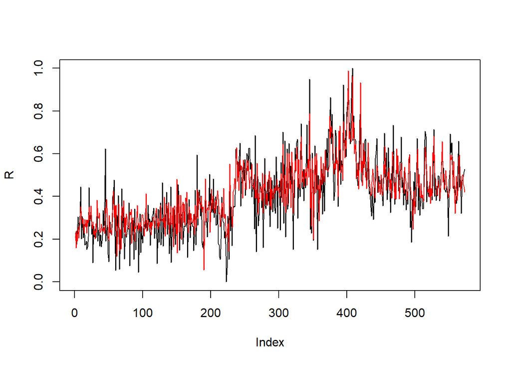

```r
R <- as.vector(Salidas[-test])
plot(R,type="l")
pred <- predict(Red, Entradas[-test])
lines(pred,col = "red")
```

```r
predictions <- predict(Red,Entradas[-train])
Pred <- predictions*(max(Z)-min(Z))+min(Z)
Pred
```

```
##                  [,1]
## oct. 2006   928.73644
## nov. 2006   847.41279
## dic. 2006  1194.65119
## ene. 2007   885.04413
## feb. 2007   858.28070
## mar. 2007   845.19171
## abr. 2007   876.19917
## may. 2007   891.78067
## jun. 2007   905.52185
## jul. 2007   873.34738
## ago. 2007   848.37286
## sept. 2007  808.61660
## oct. 2007   925.38208
## nov. 2007   822.67450
## dic. 2007  1156.49567
## ene. 2008   946.66995
## feb. 2008  1075.36069
## mar. 2008   884.36495
## abr. 2008   866.22690
## may. 2008   937.00854
## jun. 2008  1007.71471
## jul. 2008   973.58438
## ago. 2008   890.52028
## sept. 2008  731.72825
## oct. 2008   800.60533
## nov. 2008   824.53869
## dic. 2008  1218.31983
## ene. 2009   832.76696
## feb. 2009  1044.25520
## mar. 2009   808.68914
## abr. 2009   929.12394
## may. 2009   904.16427
## jun. 2009   833.67499
## jul. 2009   759.00919
## ago. 2009   775.88436
## sept. 2009  717.55896
## oct. 2009   698.21734
## nov. 2009   700.67055
## dic. 2009   888.75690
```

[output cut: 126 more lines]

```
## jul. 2020   923.26600
## ago. 2020   953.17871
## sept. 2020  889.86673
## oct. 2020   982.53424
## nov. 2020   869.79234
## dic. 2020  1800.06233
## ene. 2021  1183.17831
## feb. 2021   882.13288
## mar. 2021   983.67957
## abr. 2021   972.91813
## may. 2021   978.40595
## jun. 2021   591.36804
## jul. 2021  1115.37680
## ago. 2021  1521.70209
## sept. 2021 1134.11402
```

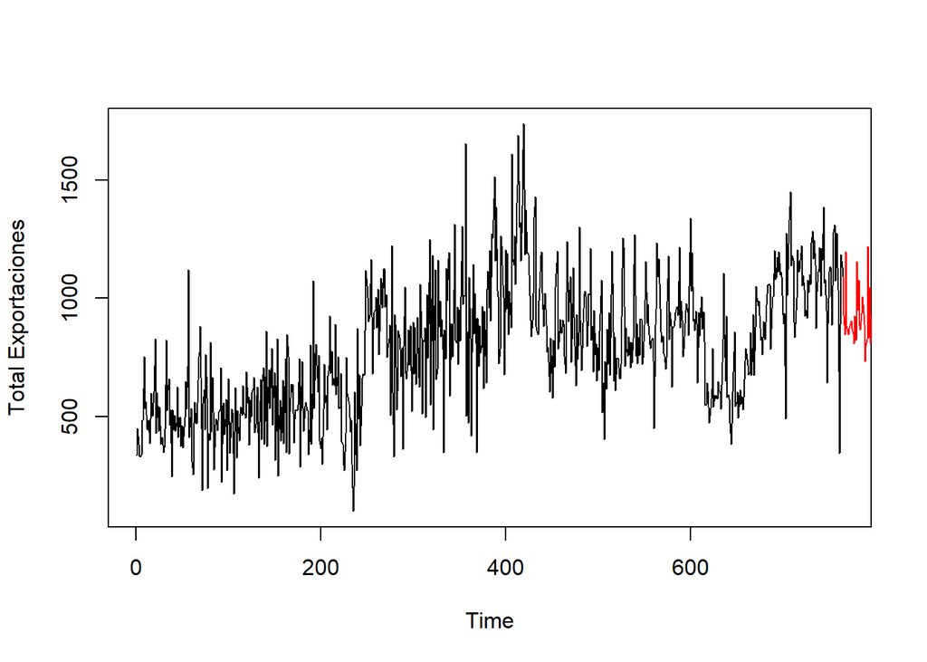

```r
x <- 1:(length(N)+length(Pred))
y <- c(as.vector(Z),Pred)
plot(x[1:length(N)], y[1:length(N)],col = "black", type="l",
     xlab="Time",ylab="Total Exportaciones")
lines( x[(length(N)):length(x)], y[(length(N)):length(x)], col="red")
```

Vemos en el gráfico que aparentemente la red ajusta bien a la serie de tiempo

Ahora vemos los datos correspondientes a las predicciones para los 8 meses posteriores a enero de 2021 Con los dos métodos vistos

```r
RNNpred=Pred[173:180,]
RNNpred
```

```
##  feb. 2021  mar. 2021  abr. 2021  may. 2021  jun. 2021  jul. 2021  ago. 2021
##   882.1329   983.6796   972.9181   978.4060   591.3680  1115.3768  1521.7021
## sept. 2021
##  1134.1140
```

```r
Predic[,1] ##Holt-Winters
```

```
##            Feb       Mar       Apr       May       Jun       Jul       Aug
## 2021 1126.8189 1044.2023  896.1104  984.0552 1040.1400 1037.0670 1103.4140
##            Sep
## 2021  993.6525
```

## Comparación de los modelos

Vamos a comparar los modelos con los datos correspondientes a la carga para el periodo de febrero de 2021 a septiembre de 2021

| Periodo Observado | Holt-Winters | Red Jordan |  |
| --- | --- | --- | --- |
| feb-2021 | 1126.8189 | 882.1329 |  |
| mar-2021 | 1044.2023 | 983.6796 |  |
| abr-2021 | 896.1104 | 972.9181 |  |
| may-2021 | 984.0552 | 978.4060 |  |
| jun-2021 | 1040.1400 | 591.3680 |  |
| jul-2021 | 1037.0670 | 1115.3768 |  |
| ago-2021 | 1103.4140 | 1521.7021 |  |
| sep-2021 | 993.6525 | 1134.1140 |  |

```r
datos.reales<-c(1274,1128,1035,345,890,1184,1131,1090)
datos.reales<-ts(datos.reales,frequency = 12,start = c(2021,2))
datos.reales
```

```
##       Feb  Mar  Apr  May  Jun  Jul  Aug  Sep
## 2021 1274 1128 1035  345  890 1184 1131 1090
```

```r
HW<-c(1126.8189,1044.2023,896.1104,984.0552,1040.1400,1037.0670,
      1103.4140, 993.6525)
HW<-ts(HW,frequency = 12,start = c(2021,2))
HW
```

```
##            Feb       Mar       Apr       May       Jun       Jul       Aug
## 2021 1126.8189 1044.2023  896.1104  984.0552 1040.1400 1037.0670 1103.4140
##            Sep
## 2021  993.6525
```

```r
RJ<-c(882.1329,983.6796,972.9181,978.4060,591.3680,1115.3768,
      1521.7021,1134.1140)
RJ<-ts(RJ,frequency = 12,start = c(2021,2))
RJ
```

```
##            Feb       Mar       Apr       May       Jun       Jul       Aug
## 2021  882.1329  983.6796  972.9181  978.4060  591.3680 1115.3768 1521.7021
##            Sep
## 2021 1134.1140
```

### Holt-Winters

```r
accuracy(HW,datos.reales)
```

```
##                 ME     RMSE      MAE       MPE     MAPE       ACF1 Theil's U
## Test set -18.55754 252.6216 178.7413 -18.25175 32.27401 0.01613588 0.4510941
```

### Red Neuronal Jordan

```r
accuracy(RJ,datos.reales)
```

```
##                 ME     RMSE      MAE       MPE     MAPE       ACF1 Theil's U
## Test set -12.83719 321.7005 254.2183 -16.66081 38.88617 -0.1911348 0.6393882
```

Vemos en este caso que el ajuste por Suavizamiento Exponencial (Holt Winters) es mejor que el de la Red Neuronal Recurrente Jordan

## Arboles de decisión

Cargamos los datos y las librerías corresponpondientes, luego

```r
## Arboles de decisión
library(readxl)
library(tidyverse)
library(rpart)
library(rpart.plot)
library(caret)
library(NTS)
Expor_cafe <- read_excel("Exportacion_cafe.xlsx",
                         col_types = c("date", "numeric"))
Expor_cafe$Año<- as.numeric(format(as.Date(Expor_cafe$MES), "%Y"))
Expor_cafe$Mes<- as.numeric(format(as.Date(Expor_cafe$MES), "%m"))
Expor_cafe$Dia<- as.numeric(format(as.Date(Expor_cafe$MES), "%d"))
tdx = c(1:length(Expor_cafe$`Total Exportaciones`))/12+1958
par(mfcol=c(2,1))
```

Graficamos la serie de tiempo y la autocorrelacion de un año completo

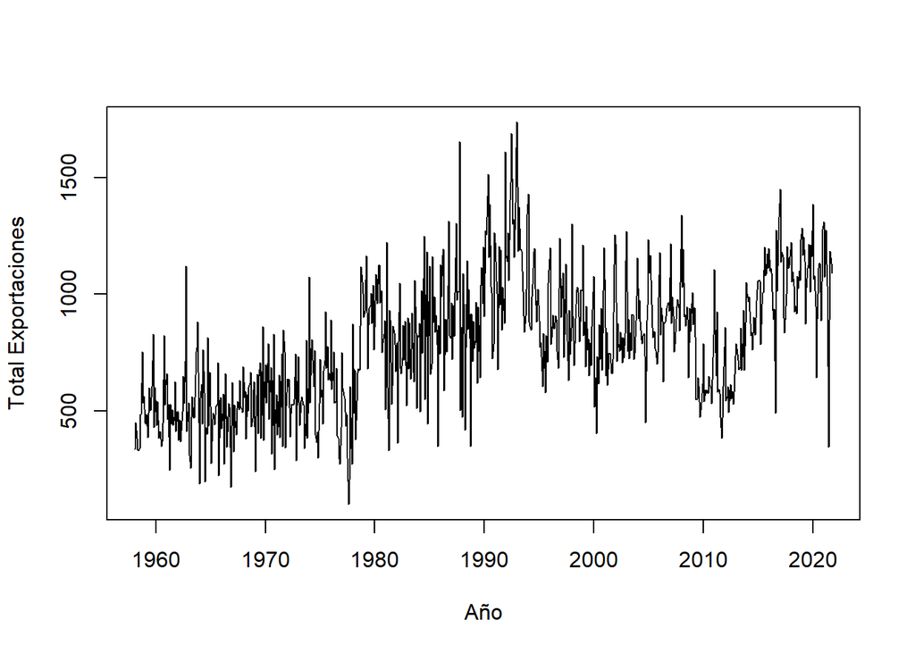

```r
plot(tdx,Expor_cafe$`Total Exportaciones`,xlab='Año',ylab='Total Exportaciones',type='l')
```

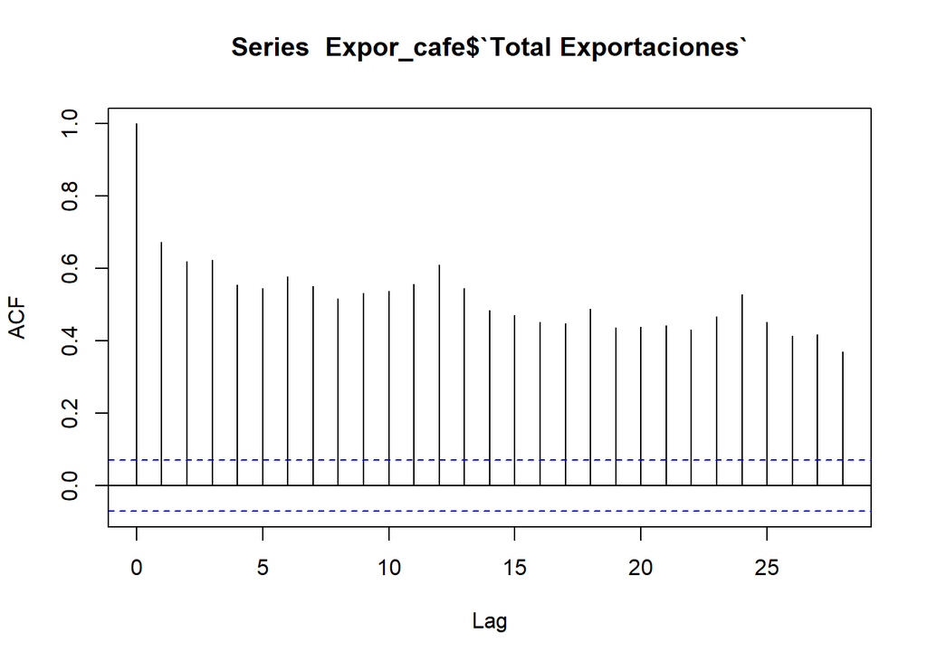

```r
acf(Expor_cafe$`Total Exportaciones`)##miramos la autocorrelación
```

```r
m1 = NNsetting(Expor_cafe$`Total Exportaciones`,nfore=12,lags=c(1:2,11:12))
names(m1)
```

```
## [1] "X"     "y"     "predX" "predY"
```

```r
X= m1$X; y = m1$y; predX = m1$predX; predY = m1$predY
```

Creamos un primer árbol de decisión

```r
t1 = tree::tree(y~.,data=data.frame(X))
```

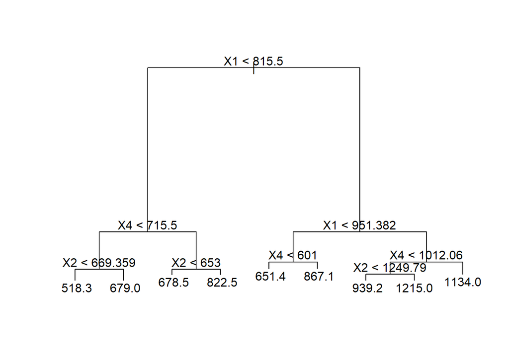

```r
par(mfcol=c(1,1))
plot(t1)
text(t1,pretty=0)
```

Hallamos los errores de una primera prediccion y luego el promedio de estos errores al cuadrado con un valor de 234.14

```r
pt1 = predict(t1,newdata=data.frame(predX)) ###Prediccion sobre la muestra de prueba
er3 = pt1-predY ###Errores de prediccion
mean(abs(er3))
```

```
## [1] 183.9302
```

```r
sqrt(mean(er3^2)) ###Promedio de los errores de prediccion al cuadrado
```

```
## [1] 234.1406
```

Ahora hallamos los residuales del modelo

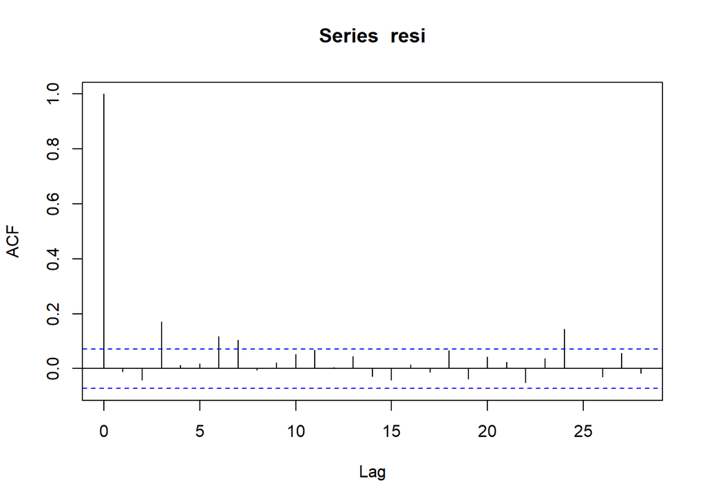

```r
pp1 =predict(t1,newdata=data.frame(X))
resi= y-pp1
acf(resi)
```

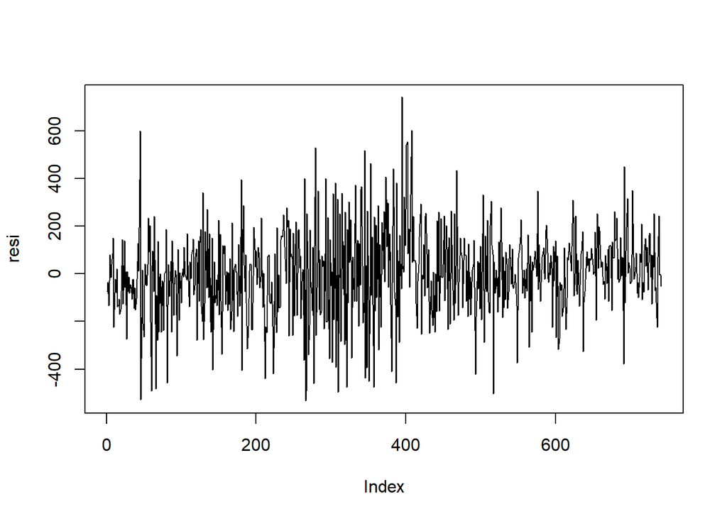

```r
plot(resi,type='l')
```

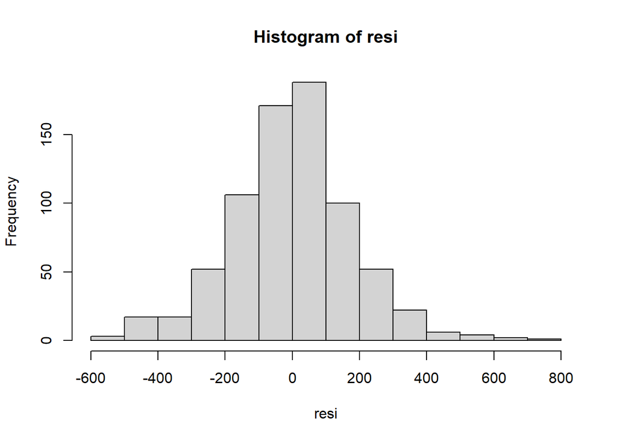

```r
hist(resi)
```

Luego hacemos la poda del arbol, donde nos damos cuenta que el tama?o del arbol es de 9 y lo graficamos luego de podarlo. A su vez, se calcula el promedio de los errores al cuadrado luego de la poda con un valor de 267.78

```r
library(tree)
```

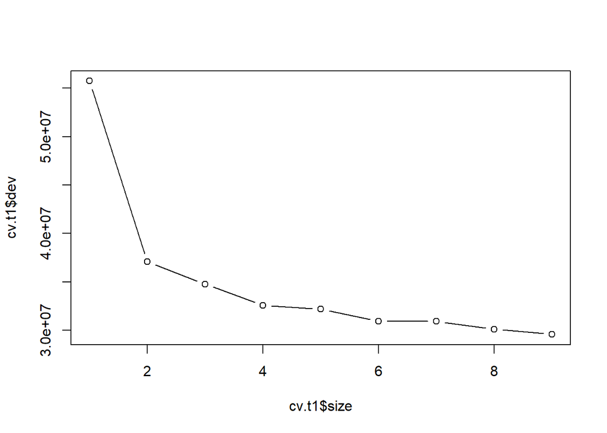

```r
cv.t1 = cv.tree(t1)
plot(cv.t1$size,cv.t1$dev,type="b")
```

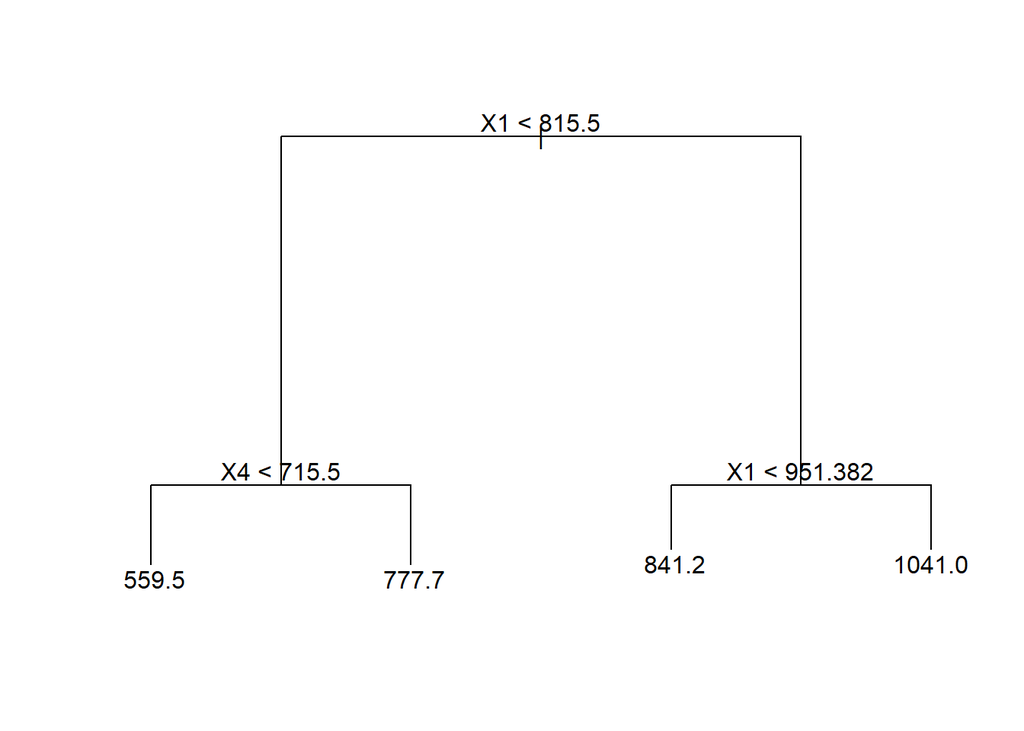

```r
prune.t1= prune.tree(t1,best=4)
plot(prune.t1)   ####Gráfica de árbol con la poda
text(prune.t1,pretty=0)
```

```r
prun = predict(prune.t1,newdata=data.frame(predX))
per =predY-prun
mean(abs(per))
```

```
## [1] 196.8556
```

```r
sqrt(mean(per^2))
```

```
## [1] 267.7769
```

Luego de podar el abol se hallan los residuales del modelo

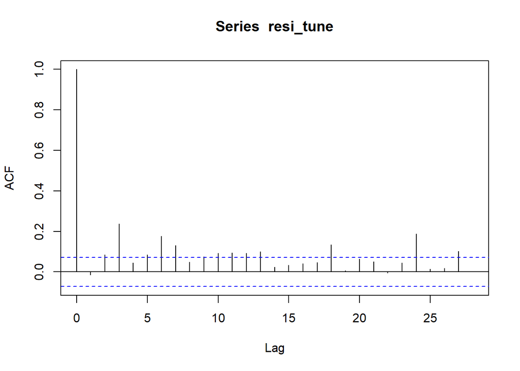

```r
pp1_tune =predict(prune.t1,newdata=data.frame(X))
resi_tune= y-pp1_tune
acf(resi_tune)
```

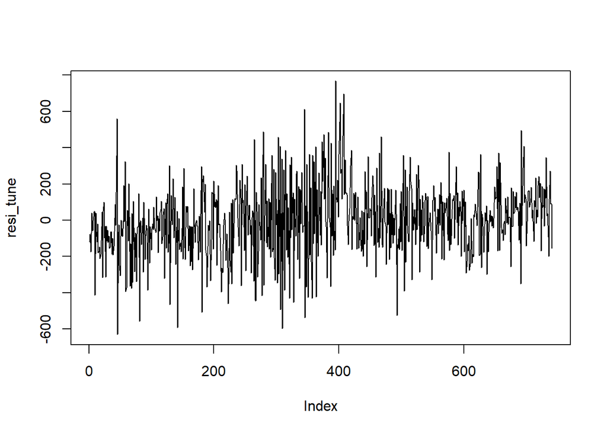

```r
plot(resi_tune,type='l')
```

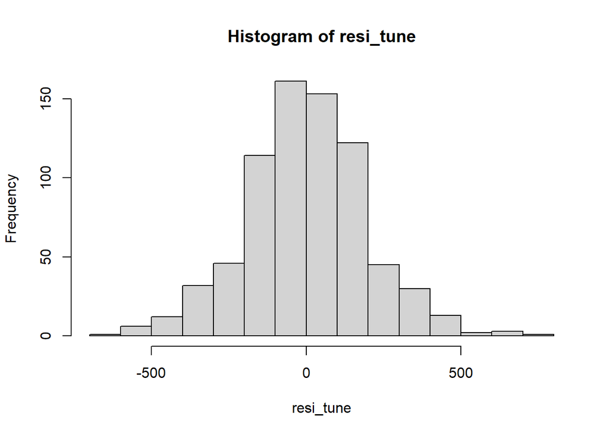

```r
hist(resi_tune)
```

Ahora calcumlamos el pronostico para los el periodo comprendido de Enero de 2021 a Septiembre de 2021 con el fin de compararlos con los datos originales y asi mismo con los otros modelos

```r
h=9
T_length=length(Expor_cafe$`Total Exportaciones`)
T_h=T_length-9
M1_pronostico=NNsetting(Expor_cafe$`Total Exportaciones`,nfore=9,lags=c(1:2,11:12))
names(M1_pronostico)
```

```
## [1] "X"     "y"     "predX" "predY"
```

```r
#y_1,y_2, y y_11,y_12
pronostico=rep(0,h)
M1_pronostico_predX_original= M1_pronostico$predX
```

```r
pron_final=predict(prune.t1,newdata=data.frame(M1_pronostico_predX_original))
pron_final
```

```
##         1         2         3         4         5         6         7         8
## 1041.2027 1041.2027 1041.2027 1041.2027 1041.2027  777.6666  841.2370 1041.2027
##         9
## 1041.2027
```

Finalmente comparamos estos datos con la datos reales correspondientes al periodo de febrero de 2021 a septiembre de 2021

```r
AD<-c(1041.2027,1041.2027,1041.2027,1041.2027,777.6666,
      841.2370, 1041.2027,1041.2027)
AD<-ts(AD,frequency = 12,start = c(2021,2))
AD
```

```
##            Feb       Mar       Apr       May       Jun       Jul       Aug
## 2021 1041.2027 1041.2027 1041.2027 1041.2027  777.6666  841.2370 1041.2027
##            Sep
## 2021 1041.2027
```

```r
accuracy(datos.reales,AD)
```

```
##                 ME     RMSE      MAE       MPE    MAPE       ACF1 Theil's U
## Test set -26.36002 293.0476 201.9614 -3.966856 20.8321 0.03024889  2.300738
```

Vemos un RMSE de 293.0476 y podemos afirmar que hace un ajuste mejor que la red neuronal jordan pero no es mejor que el suavizamiento exponencial Holt-Winters